# Assignement Coursera Practical machine learning

PHILIPPE Romain

15 novembre 2015

The goal of this project is to predict the manner in which people do the exercises. This exercises are divided in 5 classes : A,B,C,D and E. In this project, I will define the model I build, how I use cross validation, what is the sample error and I will explain my choices.

The first line of my code is set.seed() function, in order to have a reproducible experience.

## 1. Exploratory

```r
set.seed(123333)
setwd("C:/Users/Romain/Documents/MOOC/Machine learning/project1")
pmlTraining<-read.csv2("pml-training.csv", sep=",")
library(caret)
library(dplyr)

pmlTraining[,7:159] <- sapply(pmlTraining[,7:159],as.numeric)

vectorIndex<-nearZeroVar(pmlTraining,saveMetrics=F)
subsetTraining<-pmlTraining[,-vectorIndex]
ncol<-ncol(subsetTraining)
```

Before beginning any computations, I cast all the columcs from factor to numeric. After loading the provided dataset, I noticed that there is a lot of regressors, about 160. So we have to reduce this regressors. The first method is to use the nearZeroVar command. And we remove this columns of the dataset.The number of columns after : 100.

```r
library(caret)
#removing columns with lots of NA
subsetTraining<-subsetTraining[, colSums(is.na(subsetTraining)) < 10000]
dim(subsetTraining)
```

```
## [1] 19622    59
```

```r
subsetTraining<-subsetTraining[,c(-1,-2,-3,-4,-5)]
ncol<-ncol(subsetTraining)

inTrain<-createDataPartition(y=subsetTraining$classe,p=0.7,list=FALSE)
training<-subsetTraining[inTrain,]
testing<-subsetTraining[-inTrain,]
```

To end the cleaning of the data, we decide to remove the first five columns which are name and date of the exercices. It is a non-sense to put these columns into my model, it could overfit the model.

We divide our dataset into groups with a probability equals to 0.7

## 2. Model and cross validation

We use the train command with the default method => random forest and we define trControl option with the “cv” value for cross validation.

```r
library(randomForest)
rfModel <- train(classe ~ ., method = "rf", data = training, importance = T,
               trControl = trainControl(method = "cv", number = 3))
```

Then, we apply our model to the test dataset:

```r
predictions<-predict(rfModel,testing)
confusionMatrix<-confusionMatrix(predictions,testing$classe)
```

We can observe that we have a very good accuracy.

## 3. Plot and error in our model

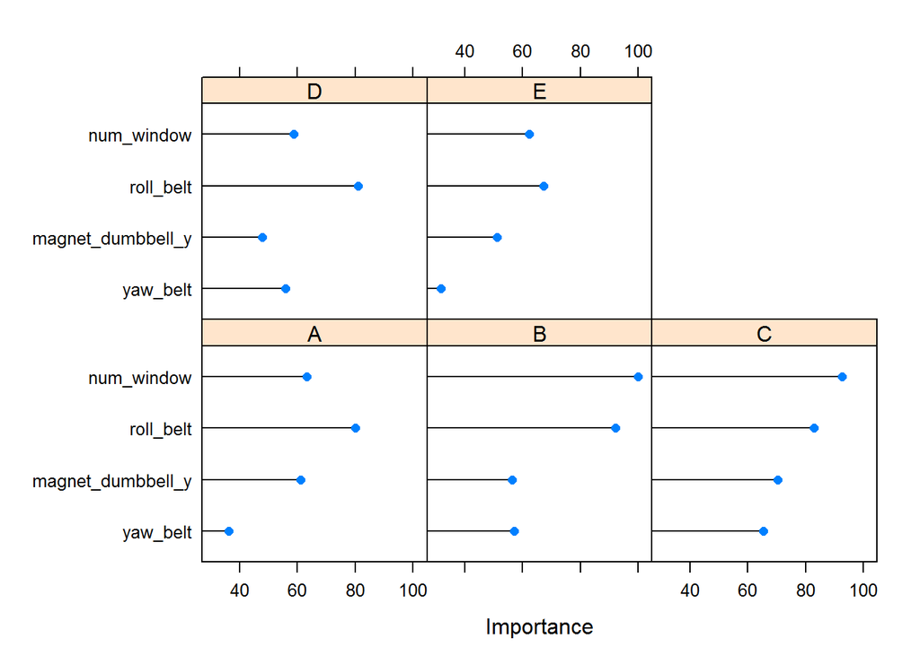

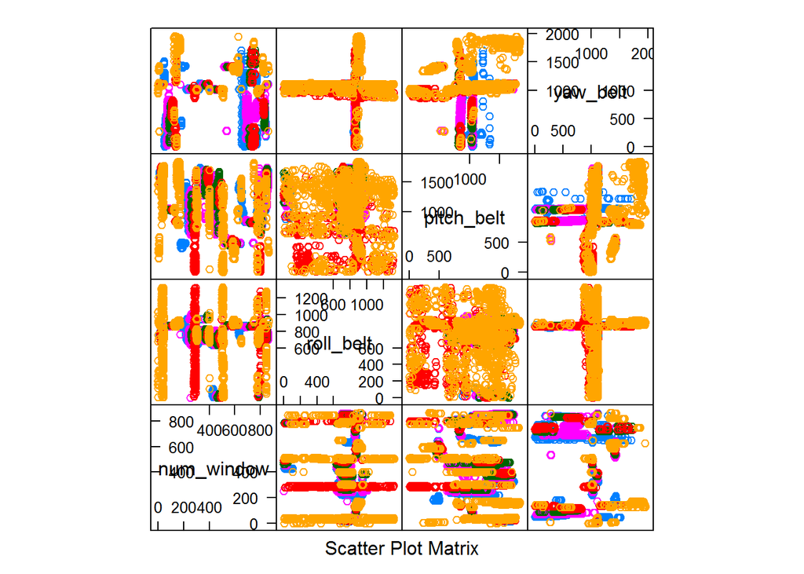

```
## Confusion Matrix and Statistics
##
##           Reference
## Prediction    A    B    C    D    E
##          A 1674    1    0    0    0
##          B    0 1138    1    0    4
##          C    0    0 1024    3    1
##          D    0    0    0  959    4
##          E    0    0    1    2 1073
##
## Overall Statistics
##
##                Accuracy : 0.9971
##                  95% CI : (0.9954, 0.9983)
##     No Information Rate : 0.2845
##     P-Value [Acc > NIR] : < 2.2e-16
##
##                   Kappa : 0.9963
##  Mcnemar's Test P-Value : NA
##
## Statistics by Class:
##
##                      Class: A Class: B Class: C Class: D Class: E
## Sensitivity            1.0000   0.9991   0.9981   0.9948   0.9917
## Specificity            0.9998   0.9989   0.9992   0.9992   0.9994
## Pos Pred Value         0.9994   0.9956   0.9961   0.9958   0.9972
## Neg Pred Value         1.0000   0.9998   0.9996   0.9990   0.9981
## Prevalence             0.2845   0.1935   0.1743   0.1638   0.1839
## Detection Rate         0.2845   0.1934   0.1740   0.1630   0.1823
## Detection Prevalence   0.2846   0.1942   0.1747   0.1636   0.1828
## Balanced Accuracy      0.9999   0.9990   0.9986   0.9970   0.9955
```

## 4. Submission with the testing dataset

We have to apply a similar processing, that is to say we remove the columns (nearZeroVar, columns with lots of NA, and name /date). Then we display our prediction.

```r
#prediction testing dataset =>Submission
pmlTesting<-read.csv2("pml-testing.csv", sep=",")
pmlTesting[,7:159] <- sapply(pmlTesting[,7:159],as.numeric)

subsetTesting<-pmlTesting[,-vectorIndex]
subsetTesting<-subsetTesting[, colSums(is.na(subsetTesting)) != nrow(subsetTesting)]
subsetTesting<-subsetTesting[,c(-1,-2,-3,-4,-5)]

predictions<-predict(rfModel,subsetTesting)
as.character(predictions)
```

```
##  [1] "B" "A" "A" "A" "A" "E" "A" "A" "A" "A" "A" "A" "D" "A" "A" "A" "A"
## [18] "B" "B" "A"
```

```r
pml_write_files = function(x){
  n = length(x)
  for(i in 1:n){
    filename = paste0("problem_id_",i,".txt")
    write.table(x[i],file=filename,quote=FALSE,row.names=FALSE,col.names=FALSE)
  }
}
pml_write_files(as.character(predictions))
```